# COVID-19 Analysis

## COVID-19 Analysis

#### This is the companion code for the data scientist blog project

#### There are 3 datasets used in this project sourced from below:

https://github.com/CSSEGISandData/COVID-19/tree/master/csse_covid_19_data

The data is downloaded as of 03/07/2020 CST

### This analysis is aiming at answering following questions of interest:

1. How many phases of infections there are in the observed virus trasimission process?
2. Does the virus transmit similarly in different areas/states?
3. How is the situation in China now at 3 months after the outbreak? Will it get cleared soon?
4. How long it will take to see the panic outbreak in the US and when it will clear out?

```python
# Libararies
import numpy as np
import pandas as pd
import matplotlib.pyplot as plt
from scipy.optimize import curve_fit
```

## Data Process

```python
# Load data
df1 = pd.read_csv('./Data/time_series_19-covid-Confirmed.csv')
df2 = pd.read_csv('./Data/time_series_19-covid-Deaths.csv')
df3 = pd.read_csv('./Data/time_series_19-covid-Recovered.csv')
df1.head()
```

|  | Province/State | Country/Region | Lat | Long | 1/22/20 | 1/23/20 | 1/24/20 | 1/25/20 | 1/26/20 | 1/27/20 | ... | 2/26/20 | 2/27/20 | 2/28/20 | 2/29/20 | 3/1/20 | 3/2/20 | 3/3/20 | 3/4/20 | 3/5/20 | 3/6/20 |
| --- | --- | --- | --- | --- | --- | --- | --- | --- | --- | --- | --- | --- | --- | --- | --- | --- | --- | --- | --- | --- | --- |
| 0 | Anhui | Mainland China | 31.8257 | 117.2264 | 1 | 9 | 15 | 39 | 60 | 70 | ... | 989 | 989 | 990 | 990 | 990 | 990 | 990 | 990 | 990 | 990 |
| 1 | Beijing | Mainland China | 40.1824 | 116.4142 | 14 | 22 | 36 | 41 | 68 | 80 | ... | 400 | 410 | 410 | 411 | 413 | 414 | 414 | 418 | 418 | 422 |
| 2 | Chongqing | Mainland China | 30.0572 | 107.8740 | 6 | 9 | 27 | 57 | 75 | 110 | ... | 576 | 576 | 576 | 576 | 576 | 576 | 576 | 576 | 576 | 576 |
| 3 | Fujian | Mainland China | 26.0789 | 117.9874 | 1 | 5 | 10 | 18 | 35 | 59 | ... | 294 | 296 | 296 | 296 | 296 | 296 | 296 | 296 | 296 | 296 |
| 4 | Gansu | Mainland China | 36.0611 | 103.8343 | 0 | 2 | 2 | 4 | 7 | 14 | ... | 91 | 91 | 91 | 91 | 91 | 91 | 91 | 91 | 102 | 119 |

5 rows × 49 columns

### There are a few things needs to be addressed here:

1. These 3 datasets are wide format, but for forecasting/modeling I need the long format, so I will need to **transpose** these 3 data
1. Confirmed case, cured case and death cases are in separate files and I will need to **merge** them together into 1 file
1. There are many countries and regions in the dataset, for this analysis, I will only focus on US and Mainland China </font>

```python
# Transpose
df1 = df1.melt(id_vars=['Province/State', 'Country/Region', 'Lat', 'Long'],
               var_name='updateDate', value_name='confirmed')
df2 = df2.melt(id_vars=['Province/State', 'Country/Region', 'Lat', 'Long'],
               var_name='updateDate', value_name='death')
df3 = df3.melt(id_vars=['Province/State', 'Country/Region', 'Lat', 'Long'],
               var_name='updateDate', value_name='recovered')
```

```python
# Merge
df = df1.merge(df2, left_on=['Province/State', 'Country/Region', 'Lat', 'Long', 'updateDate'],
          right_on=['Province/State', 'Country/Region', 'Lat', 'Long', 'updateDate'],
          how='inner')
df = df.merge(df3, left_on=['Province/State', 'Country/Region', 'Lat', 'Long', 'updateDate'],
          right_on=['Province/State', 'Country/Region', 'Lat', 'Long', 'updateDate'],
          how='inner')
```

```python
# Filters and drop unused columns
df = df[df['Country/Region'].isin(['US', 'Mainland China'])]
df.drop(['Lat', 'Long'], axis=1, inplace=True)

df['updateDate'] = pd.to_datetime(df.updateDate)
df = df.sort_values(['Country/Region', 'Province/State', 'updateDate'], ascending=[1,1,0])
df.loc[(df['Country/Region']=='Mainland China'), 'Country/Region'] = 'China'
```

```python
# Check the latest data
latest_dt = df['updateDate'].max()

print(df[(df['Country/Region']=='China') & (df['updateDate']==latest_dt)])
print(df[(df['Country/Region']=='US') & (df['updateDate']==latest_dt)])
```

```
      Province/State Country/Region updateDate  confirmed  death  recovered
8756           Anhui          China 2020-03-06        990      6        979
8757         Beijing          China 2020-03-06        422      8        299
8758       Chongqing          China 2020-03-06        576      6        513
8759          Fujian          China 2020-03-06        296      1        284
8760           Gansu          China 2020-03-06        119      2         87
8761       Guangdong          China 2020-03-06       1352      7       1216
8762         Guangxi          China 2020-03-06        252      2        217
8763         Guizhou          China 2020-03-06        146      2        114
8764          Hainan          China 2020-03-06        168      6        158
8765           Hebei          China 2020-03-06        318      6        305
8766    Heilongjiang          China 2020-03-06        481     13        396
8767           Henan          China 2020-03-06       1272     22       1244
8768           Hubei          China 2020-03-06      67592   2931      42033
8769           Hunan          China 2020-03-06       1018      4        955
```

[output cut: 140 more lines]

**For US, the data is actually at County level instead of state. So firstly I will need to aggregate to the state level.**

**For China, state value will be missing, I will impute it with province to keep the format/structure consisitent.** </font>

```python
# Extract State
df['state']=df['Province/State'].str.split(',').str[1]
# fix the Princess Diamond cases
df['state']=df['state'].str.split('(').str[0]

# Impute missing with Province/State value for Mainland China
df.loc[(df['Country/Region']=='China'), 'state'] = df['Province/State']

# Impute unassigned US Princess Diamond as XX
df.loc[(df['state'].isna()), 'state']='XX'
# print(df['state'].value_counts(dropna=False))

df['state']=df['state'].str.strip()
df.drop(['Province/State'], axis=1, inplace=True)
```

```python
# Aggregate by state
df = df.rename(columns={'Country/Region':'country'})
df = df.groupby(['country', 'state', 'updateDate']).agg({'confirmed':'sum', 'death':'sum', 'recovered':'sum'}).reset_index()
df['days']=(df['updateDate']-pd.to_datetime('2020-1-22')).dt.days
```

```python
# Check again
print(df[(df['country']=='China') & (df['updateDate']==latest_dt)])
print(df[(df['country']=='US') & (df['updateDate']==latest_dt)])
```

```
     country           state updateDate  confirmed  death  recovered  days
44     China           Anhui 2020-03-06        990      6        979    44
89     China         Beijing 2020-03-06        422      8        299    44
134    China       Chongqing 2020-03-06        576      6        513    44
179    China          Fujian 2020-03-06        296      1        284    44
224    China           Gansu 2020-03-06        119      2         87    44
269    China       Guangdong 2020-03-06       1352      7       1216    44
314    China         Guangxi 2020-03-06        252      2        217    44
359    China         Guizhou 2020-03-06        146      2        114    44
404    China          Hainan 2020-03-06        168      6        158    44
449    China           Hebei 2020-03-06        318      6        305    44
494    China    Heilongjiang 2020-03-06        481     13        396    44
539    China           Henan 2020-03-06       1272     22       1244    44
584    China           Hubei 2020-03-06      67592   2931      42033    44
629    China           Hunan 2020-03-06       1018      4        955    44
```

[output cut: 43 more lines]

### Now that data is cleaned, next step is to check the trend and to evaluate which model could be used.

### Starting with confrimed cases. Since Hubei number is sooo much higher than the rest, will check Hubei first

```
Text(0.5,1,'Figure 1: Hubei COVID-19 Confirmed Time Trend')
```

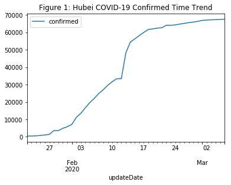

```python
# Hubei stands out by itself
df_hubei = df[df['state']=='Hubei']
df_hubei.plot(x='updateDate', y=['confirmed'])
plt.title('Figure 1: Hubei COVID-19 Confirmed Time Trend')
```

```python
# The rest province in China are more or less in the same scale
df_china = df[(df['country']=='China') & (df['state']!='Hubei')]
```

```python
def plot_group(data, x, y, group, time, measure, title):
    '''
    This is to visualize the time trend of confirmed/recovered/death counts by group for this project
    data: dataframe containing the data, need to have updateDate, group, and measure columns
    x, y: plot size
    group: group by variable
    measure: tracking varaible, can be confirmed, recovered, or death
    title_text: title for the plot
    '''
    fig, ax = plt.subplots(figsize=(x,y))
    for key, grp in data.groupby(group):
        ax.plot(grp[time], grp[measure], label=key)

    plt.title(title)
    ax.legend()
    plt.show()
```

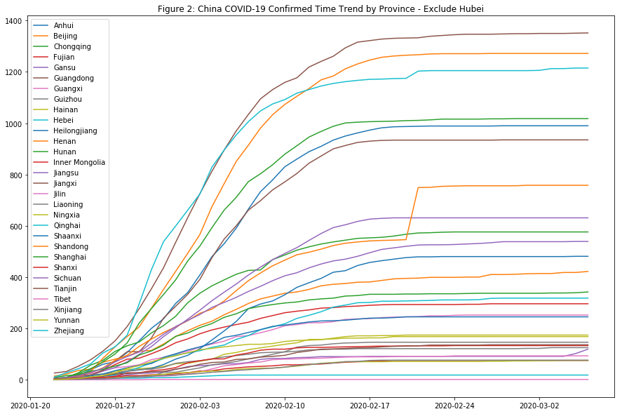

```python
# check the trend
plot_group(df_china, 15, 10, 'state', 'updateDate','confirmed', 'Figure 2: China COVID-19 Confirmed Time Trend by Province - Exclude Hubei')
```

### __Above two plots indicate the spreading of COVID-19 is a sigma shape curve, which means we could use some survival / non-linear models to describe its behavior and make predictions.__

### **This answers Question 1, there are roughly 3 phases in the transimission process:**

- **Discovery phase** ( first a couple weeks), confirmed cases slowly increase, probably limited by the diagnose capability
- **Exploding phase** ( following 2-3 weeks), confirmed cases fast increase, likeyly majority of the infected patients get diagnosed
- **Stable phase** ( starting 1 month afterwords): confirmed case plateaud out, probably because of prevention/isolation takes effects and the virus starts getting under control </font>

### **Figure 2 of China COVID-19 Time Trend by Province answers Question 2:**

- Different province in China all have similar S-shape trends, so it is reasonable to assume US virus spreading will follow the same trend, hence, we could use data in China to estimate US phases and times </font>

### Now checking death and recovered cases to estimate current situations in China

```python
def plot_covid(data, x, y, title_text):
    '''
    This is to visualize the time trend of confirmed/recovered/death counts for this project
    data: dataframe containing the data, need to have updateDate, confirmed, recovered, death columns
    x, y: plot size
    title_text: title for the plot
    '''
    fig, ax1 = plt.subplots(figsize=(10, 5))
    ax1.set_ylabel('Confirmed | Recovered Count')
    ax1.plot(data['updateDate'], data['recovered'], color='green')
    ax1.plot(data['updateDate'], data['confirmed'], color='blue')
    ax1.legend()

    ax2 = ax1.twinx()
    ax2.set_ylabel('Death Count', color='red')
    ax2.plot(data['updateDate'], data['death'], color='red')
    ax2.legend(loc='center left')

    plt.title(title_text)
    plt.show()
```

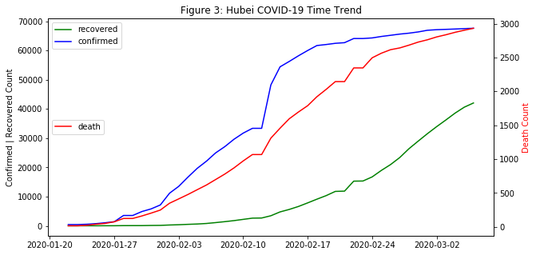

```python
# Hubei
plot_covid(df_hubei, 10, 5, 'Figure 3: Hubei COVID-19 Time Trend')
```

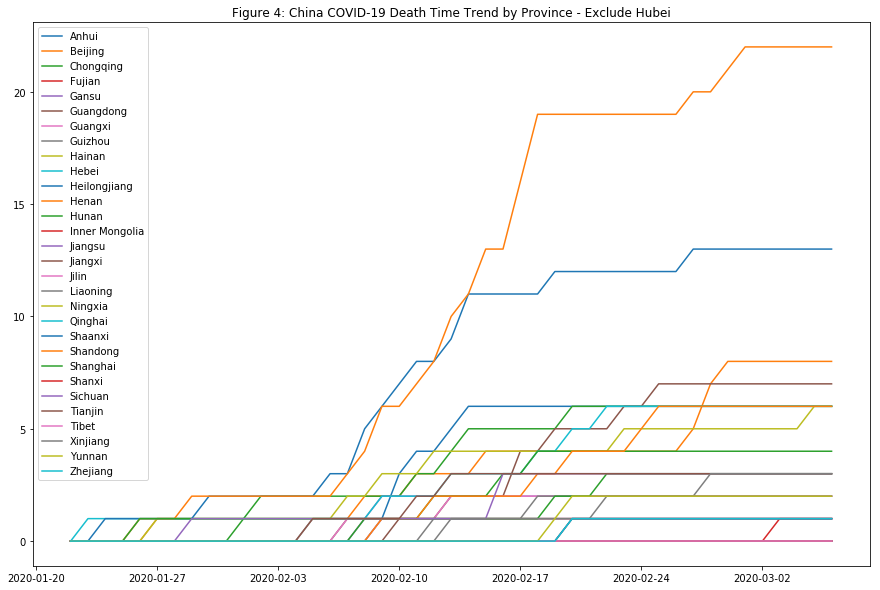

```python
# China exclude Hubei, check death first
plot_group(df_china, 15, 10, 'state', 'updateDate','death', 'Figure 4: China COVID-19 Death Time Trend by Province - Exclude Hubei')
```

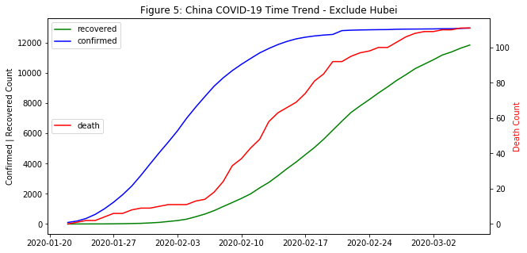

```python
# Above plot looks too noisy, aggregate together to see overall trend
df_china_all = df_china.groupby(['country', 'updateDate']).agg({'confirmed':'sum', 'death':'sum', 'recovered':'sum'}).reset_index()
plot_covid(df_china_all, 10, 5, 'Figure 5: China COVID-19 Time Trend - Exclude Hubei')
```

### __Above Figure 3 and Figure 5 can answer Question 3:__

- **Out of Hubei** ( Figure 5 ), confirmed case is plateaued out, recovered case is still increasing and the gap is starting to close out; death case shows a similar sigma shape and starts to reach the plateau
- **For Hubei** ( Figure 3 ), confirmed case still shows a tiny upward slope, recovered case is increasing, however, only a little more than half of confirmed case is recovered, death case is still increasing

Overall, it appears the COVID-19 spreading in China will get under control soon out of Hubei; For Hubei, a couple more months will be needed before things go back to normal

### Now looking at US cases and make some wild guesses :)

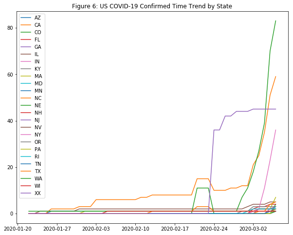

```python
# checking US
df_us = df[(df['country']=='US')]
# check the trend
plot_group(df_us, 10, 8, 'state', 'updateDate','confirmed', 'Figure 6: US COVID-19 Confirmed Time Trend by State')
```

### **Above US by State plot tells 2 things:**

- Some states like CA and WA are entering the Exploding phase already, while other states are still in Discovery phase
- There are bumps/noises in the data, and majority of the states have counts less than 10, so it's better to analysis the US as a whole </font>

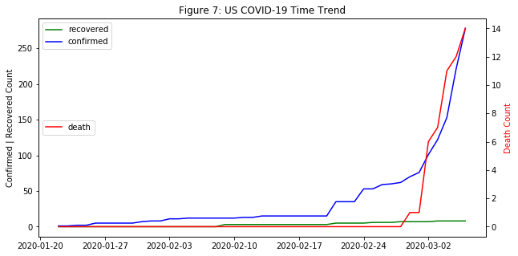

```python
# Aggregate US
df_us_all = df_us.groupby(['country', 'updateDate', 'days']).agg({'confirmed':'sum', 'death':'sum', 'recovered':'sum'}).reset_index()
# Check US again
plot_covid(df_us_all, 10, 4, 'Figure 7: US COVID-19 Time Trend')
```

### Some notes about US curent situation (Figure 7):

- There is almost no recovered cases - This actually makes sense because only 2 states (CA, WA) are in the exploding phase shown in Figure 6, and the rest are still in discovery phase, and based on overall China (Figure 5), it takes about 3 weeks before the recovered case picking up
- Both overall China (Figure 5) and Hubei (Figure 3) show the death curve rate is shallower compared to confrimed curve. However, the US curve disagrees on that as evidenced by the cross of blue and red curve in Figure 7. This may be caused by small sample size/data noise, it is alo possibly caused by incorrectly evaluation of current situation. Until a few days ago, CDC only recommends checking for COVID-19 for cases directly related to China, or other severly impacted countries/regions. So it is possible that he virus has already spreaded out, but not diagnosed/confirmed. Which means the above confirmed curve is biased and there will be large jumps in the next a couple weeks when those people are diagnosed and confirmed. At that time, the recovered and death curve should have a similar trend as in China. </font>

### Let's try to find some province in China that look like US to estimate

- how long will take the US to get panic outbreak (the mid point of the exploding phase)
- how long it will take to break out (the starting of the plateau phase) </font>

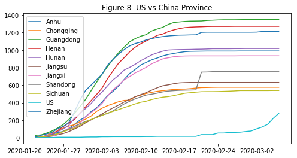

```python
# put US together with Chinese province, considering US has >250 and still in the early stage, remove Chinese provice
# that has max number < 500 to reduce noise in the data
d1 = pd.DataFrame(df_china.groupby('state')['confirmed'].max()>500)
l1 = list(d1[d1['confirmed']==True].index)
df_china2 = df_china[df_china['state'].isin(l1)]

df_us_all['state'] = 'US'
df_new = df_us_all.append(df_china2, sort=False)
plot_group(df_new, 8, 4, 'state', 'updateDate', 'confirmed', 'Figure 8: US vs China Province')
```

### It looks there is a about a month's delay between US and China, to make it more comparable, shift US dates about a month backward then compare

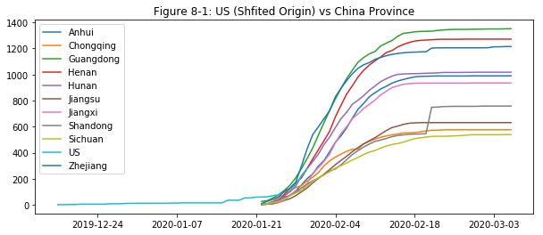

```python
# Reset US for about a month backward to align with the curves, tried a few values, 36 looks good
offset = -36
df_us_all['assumeDate'] = df_us_all['updateDate']+pd.DateOffset(offset)
df_china2.loc[:, 'assumeDate'] = df_china2['updateDate']
df_new2 = df_us_all.append(df_china2, sort=False)
plot_group(df_new2, 10, 4, 'state', 'assumeDate','confirmed', 'Figure 8-1: US (Shfited Origin) vs China Province')
```

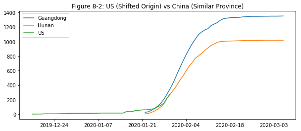

```python
# eyeball it, it looks US is roughly between Guangdong and Hunan (based on early upward trend)
df_new3 = df_new2[df_new2['state'].isin(['US', 'Guangdong', 'Hunan'])]
plot_group(df_new3, 10, 4, 'state', 'assumeDate','confirmed', 'Figure 8-2: US (Shifted Origin) vs China (Similar Province)')
```

### Assume US virus spreading will be somewhere between Guangdong and Hunan, now it is time to fit the Guangdong and Hunan curve to get parameter estimates for us

```python
def func(x, a, b, c):
    '''
    This is the functionn form of S curve
    x: days from the beginning
    a, b, c: parameters
    '''
    return a / (b + np.exp(-c*x))
```

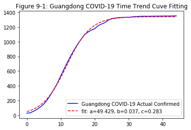

```
[4.94294961e+01 3.68678938e-02 2.82617767e-01]
```

```python
# fitting Henan
dd1 = df_new3[df_new3['state']=='Guangdong']
plt.plot(dd1['days'], dd1['confirmed'], 'b-', label='Guangdong COVID-19 Actual Confirmed')
popt, pcov = curve_fit(func, dd1['days'], dd1['confirmed'])
plt.plot(dd1['days'], func(dd1['days'], *popt), 'r--', label='fit: a=%5.3f, b=%5.3f, c=%5.3f' % tuple(popt))
plt.title("Figure 9-1: Guangdong COVID-19 Time Trend Cuve Fitting")
plt.legend()
plt.show()
upper = popt
print(upper)
```

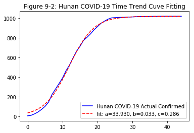

```
[3.39302498e+01 3.33477007e-02 2.85719181e-01]
```

```python
# fitting Hunan
dd2 = df_new3[df_new3['state']=='Hunan']
plt.plot(dd2['days'], dd2['confirmed'], 'b-', label='Hunan COVID-19 Actual Confirmed')
popt, pcov = curve_fit(func, dd2['days'], dd2['confirmed'])
plt.plot(dd2['days'], func(dd2['days'], *popt), 'r--', label='fit: a=%5.3f, b=%5.3f, c=%5.3f' % tuple(popt))
plt.title("Figure 9-2: Hunan COVID-19 Time Trend Cuve Fitting")
plt.legend()
plt.show()
lower = popt
print(lower)
```

### Fitting US, since we shifted US time backward, for estimation, we will need to shift the days back, then adding new dates for future predictions

```python
# Fitting US
# Because there is an offset, so we need to shift days in US by offset amount
dd3 = df_new3[df_new3['state']=='US']
dd3.loc[:, 'days'] = dd3['days']+offset

# Now setup 40 data points for forecast
current_end = dd3.days.max()+1
dd3_forecast = pd.DataFrame({"days":range(current_end, current_end+40), "state":"US", 'country':"US"})
dd3 = dd3.append(dd3_forecast, sort=False)

# Use Guangdong and Henan parameters to forecast US
dd3_upper=func(dd3['days'], upper[0], upper[1], upper[2])
dd3_lower=func(dd3['days'], lower[0], lower[1], lower[2])

dd3.loc[:, 'upper'] = dd3_upper
dd3.loc[:, 'lower'] = dd3_lower
```

```python
# Convert the forecast days back to calendar days
enddate=dd3['updateDate'].max() + pd.DateOffset(1)
# Populate missing with 1 day after the max day then correct forwards
dd3['updateDate'] = dd3['updateDate'].fillna(value = enddate)
dd3['offday'] = dd3['days']-current_end
dd3.loc[(dd3['updateDate']<enddate), 'offday']=0

dd3['forecastDate'] = dd3['updateDate'] + pd.to_timedelta(dd3['offday'], unit='D')
```

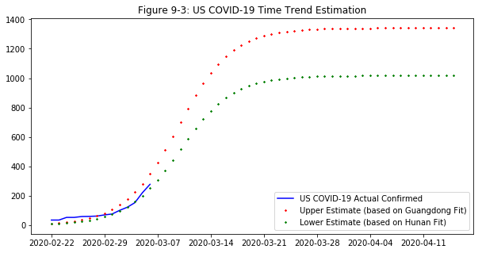

```python
# Check the final results
dd3 = dd3[dd3['days']>=-5]
plt.figure(figsize=(10, 5))
plt.plot(dd3['forecastDate'], dd3['confirmed'], 'b-', label='US COVID-19 Actual Confirmed')
plt.plot(dd3['forecastDate'], dd3['upper'], 'r*', markersize=2, label='Upper Estimate (based on Guangdong Fit)')
plt.plot(dd3['forecastDate'], dd3['lower'], 'g*', markersize=2, label='Lower Estimate (based on Hunan Fit)')
plt.title("Figure 9-3: US COVID-19 Time Trend Estimation")
plt.legend()
plt.show()
```

### __Now we can answer for Question 4__

- The panic outbreak is happening right now until end of month. If US applies similar controls/protocols as in China (isolating severe areas, active diagose and treatment), COVID-19 should be undercontrol around April. However, due to the possible under-recorded early cases, it is likely the period can be much longer and peaking cases can go higher.